# Báo Cáo Sơ Bộ - Môi Trường Sống và Sức Khỏe Hộ Gia Đình

Nhóm 5

2025-10-11

### **Chủ đề nghiên cứu:** Mối liên quan giữa điều kiện vệ sinh, nguồn nước, và sức khỏe của các thành viên trong hộ gia đình.

**Câu hỏi nghiên cứu:**

1. Mô tả tỷ lệ các hộ gia đình được tiếp cận với nguồn nước sạch và nhà tiêu hợp vệ sinh. Trực quan hóa sự chênh lệch về các chỉ số này giữa khu vực thành thị và nông thôn.
2. Kiểm định giả thuyết: Liệu các hộ gia đình sử dụng nguồn nước không an toàn có tỷ lệ trẻ em (< 5 tuổi) bị tiêu chảy cao hơn so với các hộ gia đình dùng nước sạch hay không?
3. Xây dựng mô hình hồi quy logistic để xác định các yếu tố kinh tế - xã hội (mức sống, trình độ học vấn của chủ hộ) dự đoán khả năng một hộ gia đình sở hữu nhà tiêu hợp vệ sinh.
4. Sự thay đổi của các vấn đề nghiên cứu trong vòng 20 năm qua (2000-2021) và dự báo sự thay đổi trong 10 năm tới.

**Mô tả số liệu:**

Bộ dữ liệu được lấy từ khảo sát MICS 6 (2021) của UNICEF tại Việt Nam, bao gồm các thông tin về hộ gia đình, trẻ em và các yếu tố liên quan đến sức khỏe cộng đồng.

Các biến số chính được sử dụng

- Biến phụ thuộc:
  - `WS11`: Loại nhà vệ sinh của hộ gia đình.
  - `WS1`: Nguồn nước uống chính của hộ gia đình
  - `CA1`: Trẻ có bị tiêu chảy trong 2 tuần qua không.
- Biến độc lập:
  - `HH6`: Khu vực sinh sống
  - `windex5`: Mức sống kinh tế của hộ gia đình
  - `windex5r`: Mức sống kinh tế của hộ gia đình ở nông thôn
  - `windex5u`: Mức sống kinh tế của hộ gia đình ở thành thị
  - `helevel`: Trình độ học vấn của chủ hộ
  - `HC2`: Dân tộc chủ hộ
  - `HH5Y`: Năm tiến hành nghiên cứu

## **I.**

### **1. Kết quả làm sạch dữ liệu**

**Xử lý missing:**

Bảng 1. Tỷ lệ thiếu dữ liệu trong hh.sav

| HH1 | HH2 | HH6 | WS1 | WS11 | helevel | HC2 | windex5 | windex5r | windex5u | HH5Y |
| --- | --- | --- | --- | --- | --- | --- | --- | --- | --- | --- |
| 0 | 0 | 0 | 0 | 0 | 0 | 0 | 0 | 31.50685 | 68.49315 | 0 |

Bảng 2. Tỷ lệ thiếu dữ liệu trong ch.sav

| HH1 | HH2 | CA1 | UF10 |
| --- | --- | --- | --- |
| 0 | 0 | 0 | 0 |

**Tỷ lệ dữ liệu thiếu:** đa phần các biến không có dữ liệu thiếu

- **Hai biến có tỷ lệ thiếu cao:** `windex5r` (31.5%) và `windex5u` (68.49%) do áp dụng cho nhóm khu vực khác nhau.

**Cách xử lý:**

- Giữ nguyên giá trị trong `windex5r, windex5u`.

**Các biến mới đã được tạo:**

- Biến `diarrhea`: bằng 1 nếu trẻ trong hộ được báo cáo là bị tiêu chảy trong vòng 2 tuần trước khảo sát, bằng 0 nếu không bị.
- Biến `any_diarrhea`: bằng 1 nếu trong hộ có ít nhất một trẻ bị tiêu chảy, bằng 0 nếu không có.
- Biến `safe_water`: bằng 1 nếu nguồn nước sinh hoạt thuộc nhóm an toàn (nước máy, giếng khoan), bằng 0 nếu không thuộc nhóm an toàn (nước, sông, ao hồ).
- Biến `improved_sanitation`: bằng 1 nếu hộ có nhà tiêu hợp vệ sinh và bằng 0 nếu không có.

### **2. Thống kê mô tả và trực quan hóa**

Bảng 2. Tần số hộ có nước sạch

| safe_water | n | percent |
| --- | --- | --- |
| Không | 533 | 0.0398982 |
| Có | 12826 | 0.9601018 |

Bảng 3. Tần số hộ có nhà tiêu hợp vệ sinh

| improved_sanitation | n | percent |
| --- | --- | --- |
| Không | 2752 | 0.2060034 |
| Có | 10607 | 0.7939966 |

*Nhận xét:* Khoảng 96% hộ sử dụng nguồn nước sạch và khoảng 79% hộ có nhà tiêu hợp vệ sinh, cho thấy điều kiện vệ sinh nhìn chung khá tốt.

#### *Biểu đồ tròn tỷ lệ*

##### Tỷ lệ hộ sử dụng nước sạch

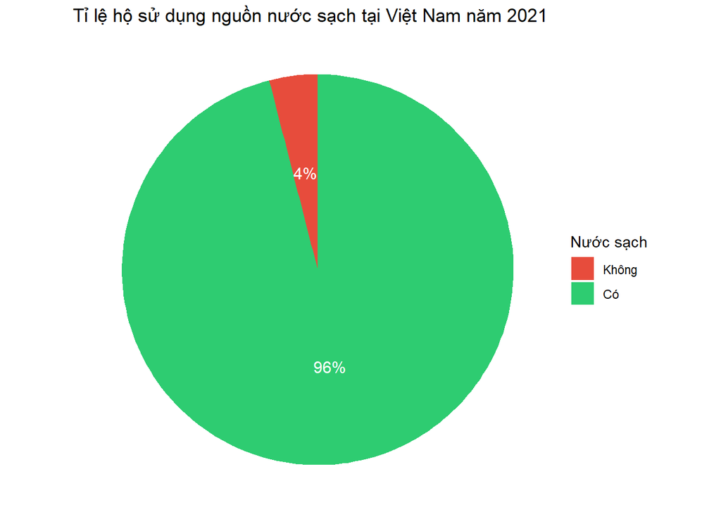

**Nhận xét:** Tỷ lệ hộ có nguồn nước sạch là 96% cho thấy đa số hộ gia đình sử dụng nước sạch, cho thấy hạ tầng cấp nước khá tốt.

##### Tỷ lệ hộ có nhà tiêu hợp vệ sinh

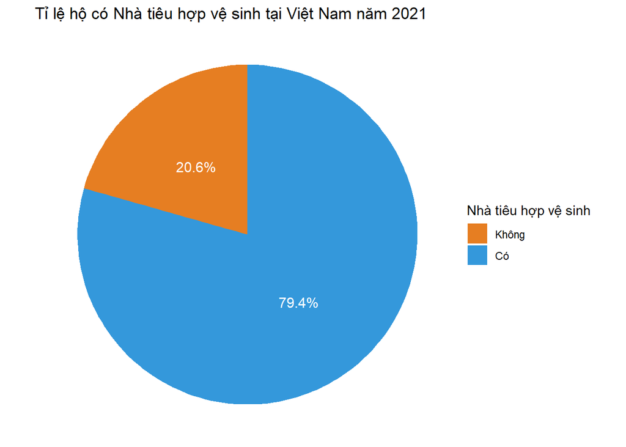

**Nhận xét:** Tỷ lệ hộ có nhà tiêu hợp vệ sinh là 79.4%, vẫn còn 20.6% hộ chưa có nhà tiêu đạt chuẩn, tiềm ẩn nguy cơ ô nhiễm.

#### *Biểu đồ cột so sánh theo khu vực*

##### Nước sạch

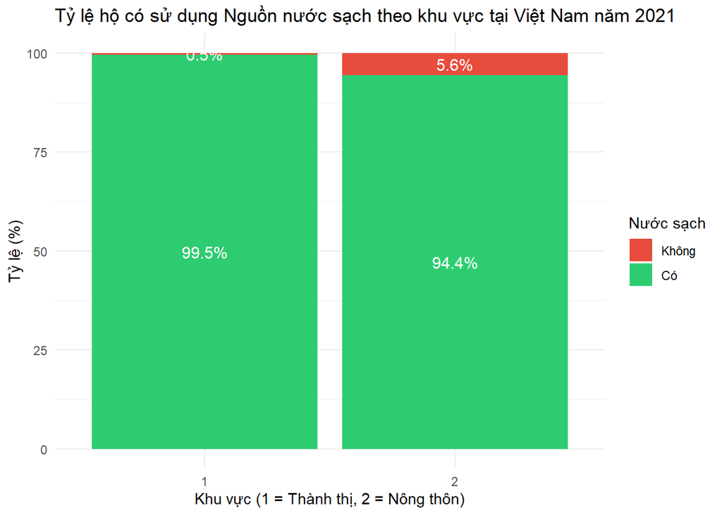

**Nhận xét:** Việt Nam đạt tỷ lệ hộ sử dụng nước sạch rất cao, đặc biệt tại khu vực thành thị. Tuy nhiên, chênh lệch giữa nông thôn và thành thị (5%) cho thấy vẫn cần tiếp tục đầu tư và cải thiện hệ thống cấp nước ở nông thôn để đảm bảo công bằng trong tiếp cận nguồn nước sạch.

##### Nhà tiêu hợp vệ sinh

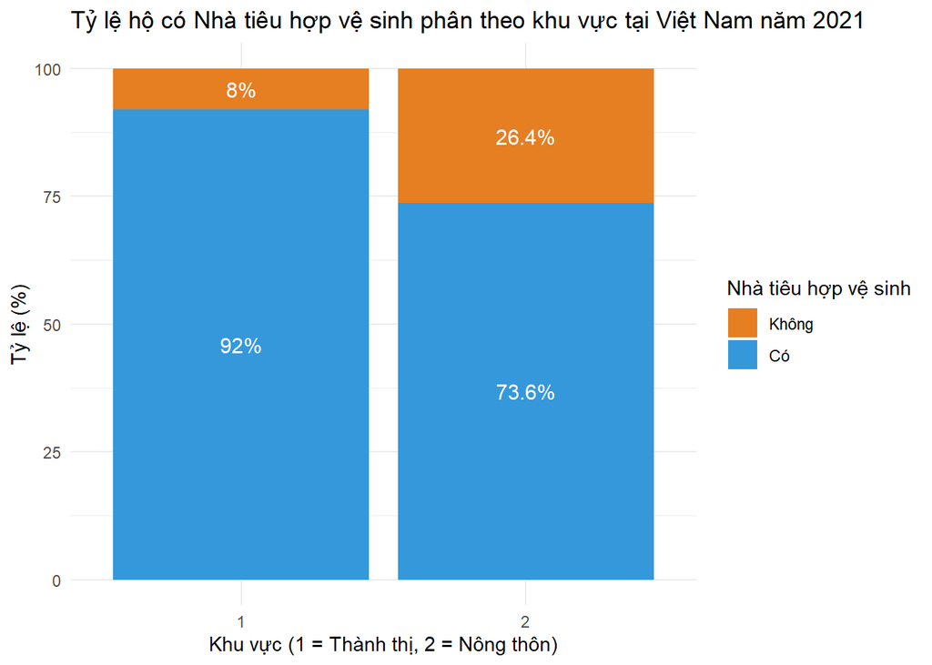

**Nhận xét:** Khu vực thành thị có điều kiện vệ sinh tốt hơn nhiều so với nông thôn. Tỷ lệ hộ có nhà tiêu hợp vệ sinh ở nông thôn thấp hơn 18.4% so với thành thị.

### **3. Kết quả phân tích mối liên quan**

#### 3.1. Kiểm định Chi-squared

Bảng 4. Bảng chéo giữa Nước sạch và Tiêu chảy

| hh6_clean.safe_water | hh6_clean.any_diarrhea | Freq |
| --- | --- | --- |
| 0 | 0 | 190 |
| 1 | 0 | 3019 |
| 0 | 1 | 30 |
| 1 | 1 | 280 |

Bảng 5. Kết quả kiểm định Chi-squared

```
##
##  Pearson's Chi-squared test with Yates' continuity correction
##
## data:  hh6_clean$safe_water and hh6_clean$any_diarrhea
## X-squared = 6.1807, df = 1, p-value = 0.01291
```

**Nhận xét:** p = 0.01291 < 0.05 -> Có mối liên hệ thống kê có ý nghĩa giữa việc sử dụng nước sạch và tình trạng tiêu chảy ở trẻ em trong mẫu khảo sát này.

#### 3.2. Phân tích hồi quy logistic

#### **3.2.1. Phân tích mối liên quan giữa yếu tố về điều kiện kinh tế và học vấn với khả năng có nhà tiêu hợp vệ sinh.**

```
##
## Call:
## glm(formula = improved_sanitation ~ windex5 + helevel + HH6 +
##     HC2, family = binomial, data = hh6_clean)
##
## Coefficients:
##             Estimate Std. Error z value Pr(>|z|)
## (Intercept) -0.27977    0.16479  -1.698   0.0896 .
## windex5      0.95219    0.03353  28.399   <2e-16 ***
## helevel      0.19517    0.02243   8.701   <2e-16 ***
## HH6         -0.14234    0.07169  -1.985   0.0471 *
## HC2         -0.13032    0.01472  -8.854   <2e-16 ***
## ---
## Signif. codes:  0 '***' 0.001 '**' 0.01 '*' 0.05 '.' 0.1 ' ' 1
##
## (Dispersion parameter for binomial family taken to be 1)
##
##     Null deviance: 13589  on 13358  degrees of freedom
## Residual deviance: 10494  on 13354  degrees of freedom
## AIC: 10504
##
## Number of Fisher Scoring iterations: 6
```

**Nhận xét:** Tất cả các biến đều có ý nghĩa thống kê. Mô hình cho thấy **điều kiện kinh tế** và **học vấn** là **yếu tố quyết định tích cực**, trong khi **khu vực và dân tộc** là rào cản đối với vệ sinh cải thiện.

- `windex5` (0.95219): Mức sống cao → xác suất có nhà tiêu hợp vệ sinh **tăng**
- `helevel` (0.19517): Học vấn chủ hộ cao → **tăng khả năng có** nhà tiêu hợp vệ sinh**.**
- `HH6` (-0.14234): Khu vực (thành thị/nông thôn) có ảnh hưởng **âm**, cho thấy khả năng có nhà tiêu hợp vệ sinh ở nông thôn kém hơn.
- `HC2` (-0.13032): Dân tộc thiểu số có khả năng có khả năng có nhà tiêu hợp vệ sinh thấp hơn.

#### **3.2.2. Phân tích mối liên quan giữa yếu tố về điều kiện kinh tế - xã hội (ở thành thị hoặc nông thôn) và học vấn với khả năng có nhà tiêu hợp vệ sinh.**

##### Điều kiện ở nông thôn

```
##
## Call:
## glm(formula = improved_sanitation ~ windex5r + helevel + HC2,
##     family = binomial, data = hh6_clean)
##
## Coefficients:
##             Estimate Std. Error z value Pr(>|z|)
## (Intercept) -0.93174    0.09366  -9.948  < 2e-16 ***
## windex5r     0.94677    0.03423  27.657  < 2e-16 ***
## helevel      0.22236    0.02561   8.683  < 2e-16 ***
## HC2         -0.08595    0.01644  -5.229  1.7e-07 ***
## ---
## Signif. codes:  0 '***' 0.001 '**' 0.01 '*' 0.05 '.' 0.1 ' ' 1
##
## (Dispersion parameter for binomial family taken to be 1)
##
##     Null deviance: 10563.6  on 9149  degrees of freedom
## Residual deviance:  8306.9  on 9146  degrees of freedom
##   (4209 observations deleted due to missingness)
## AIC: 8314.9
##
## Number of Fisher Scoring iterations: 5
```

**Nhận xét:** Ở khu vực nông thôn, mức sống và học vấn vẫn là hai yếu tố có ảnh hưởng rõ rệt nhất đến khả năng có nhà tiêu hợp vệ sinh.

- `windex5r`, `helevel`, `HC2` có ý nghĩa thống kê rất mạnh (p < 0.001).

##### Điều kiện ở thành thị

```
##
## Call:
## glm(formula = improved_sanitation ~ windex5u + helevel + HC2,
##     family = binomial, data = hh6_clean)
##
## Coefficients:
##             Estimate Std. Error z value Pr(>|z|)
## (Intercept)  0.73445    0.16472   4.459 8.24e-06 ***
## windex5u     0.70801    0.06521  10.857  < 2e-16 ***
## helevel      0.12685    0.04767   2.661  0.00779 **
## HC2         -0.07913    0.04799  -1.649  0.09921 .
## ---
## Signif. codes:  0 '***' 0.001 '**' 0.01 '*' 0.05 '.' 0.1 ' ' 1
##
## (Dispersion parameter for binomial family taken to be 1)
##
##     Null deviance: 2343.2  on 4208  degrees of freedom
## Residual deviance: 2070.9  on 4205  degrees of freedom
##   (9150 observations deleted due to missingness)
## AIC: 2078.9
##
## Number of Fisher Scoring iterations: 6
```

**Nhận xét:** Ở thành thị, các yếu tố mức sống và học vấn vẫn là yếu tố chính quyết định việc có nhà tiêu hợp vệ sinh.

- `windex5u` có ý nghĩa thống kê (p < 0.001).

## **II. Sự thay đổi của các vấn đề trong 20 năm (2000-2021)**

### **1. Xu hướng và Dự báo Chuỗi thời gian (2000-2021)**

#### Trực quan hóa Xu hướng Tỷ lệ Tiếp cận nước sạch và Nhà tiêu hợp vệ sinh

##### Nguồn nước sạch

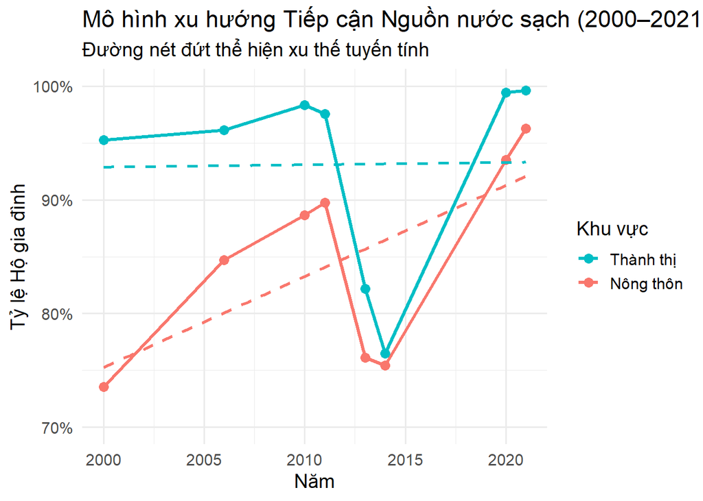

##### Nhà tiêu Hợp vệ sinh

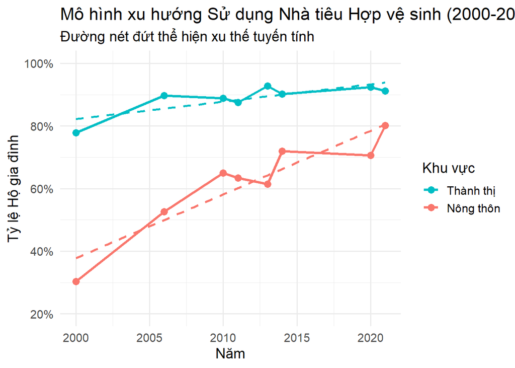

________________

#### **Mô hình hóa và Dự báo bằng ARIMA**

Do dữ liệu được thu thập không đều -> Sử dụng phương pháp **nội suy tuyến tính** để tạo chuỗi thời gian hàng năm, sau đó áp dụng mô hình `auto.arima` để tìm ra mô hình phù hợp nhất và dự báo cho 10 năm tới.

##### Nguồn nước - Nông thôn

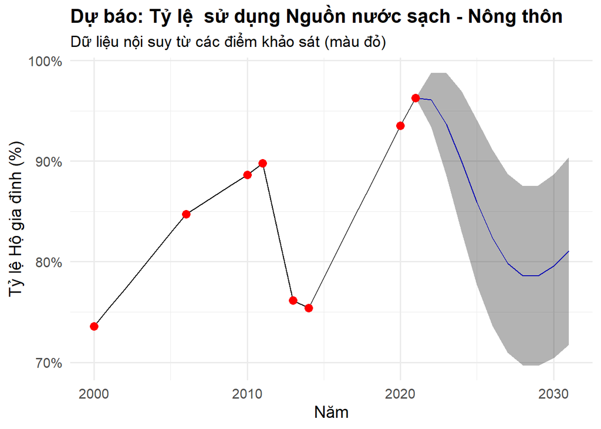

```
##
## **Mô hình ARIMA cho Tỷ lệ  sử dụng Nguồn nước sạch - Nông thôn**
## Series: ts_object
## ARIMA(2,0,0) with non-zero mean
##
## Coefficients:
##          ar1      ar2    mean
##       1.5955  -0.7807  0.8379
## s.e.  0.1290   0.1392  0.0225
##
## sigma^2 = 0.0004484:  log likelihood = 53.45
## AIC=-98.9   AICc=-96.55   BIC=-94.54
##
## Training set error measures:
##                        ME      RMSE        MAE        MPE     MAPE      MASE
## Training set 0.0007891903 0.0196785 0.01368366 0.03731916 1.661774 0.5587208
##                   ACF1
## Training set 0.1448319
```

##### Nhà tiêu - Nông thôn

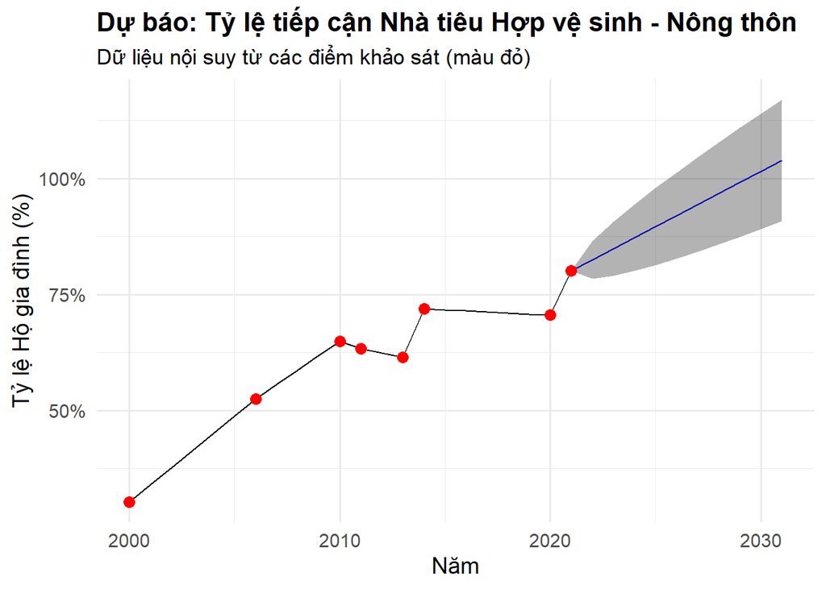

```
##
## **Mô hình ARIMA cho Tỷ lệ tiếp cận Nhà tiêu Hợp vệ sinh - Nông thôn**
## Series: ts_object
## ARIMA(0,1,0) with drift
##
## Coefficients:
##        drift
##       0.0238
## s.e.  0.0069
##
## sigma^2 = 0.001047:  log likelihood = 42.76
## AIC=-81.53   AICc=-80.86   BIC=-79.44
##
## Training set error measures:
##                        ME       RMSE        MAE       MPE     MAPE      MASE
## Training set 1.268314e-05 0.03085072 0.02388883 0.2354046 3.780065 0.8409385
##                      ACF1
## Training set 0.0003986401
```

##### Nguồn nước - Thành thị

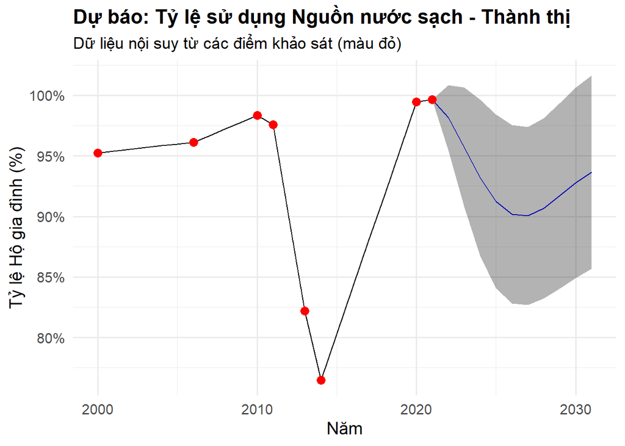

```
##
## **Mô hình ARIMA cho Tỷ lệ sử dụng Nguồn nước sạch - Thành thị**
## Series: ts_object
## ARIMA(2,0,0) with non-zero mean
##
## Coefficients:
##          ar1      ar2    mean
##       1.5118  -0.7578  0.9295
## s.e.  0.1193   0.1189  0.0173
##
## sigma^2 = 0.0004496:  log likelihood = 53.65
## AIC=-99.29   AICc=-96.94   BIC=-94.93
##
## Training set error measures:
##                         ME       RMSE        MAE         MPE     MAPE      MASE
## Training set -3.620366e-05 0.01970618 0.01447793 -0.06057895 1.629984 0.6318941
##                   ACF1
## Training set 0.1385264
```

##### Nhà tiêu - Thành thị

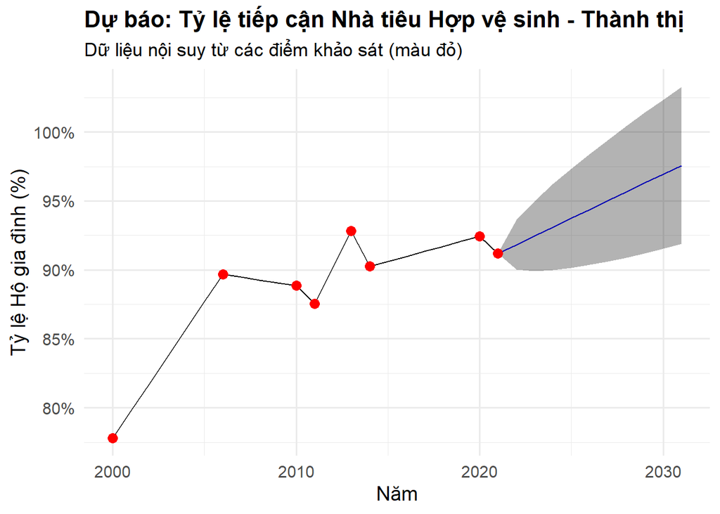

```
##
## **Mô hình ARIMA cho Tỷ lệ tiếp cận Nhà tiêu Hợp vệ sinh - Thành thị**
## Series: ts_object
## ARIMA(0,1,0) with drift
##
## Coefficients:
##        drift
##       0.0064
## s.e.  0.0030
##
## sigma^2 = 0.0001972:  log likelihood = 60.3
## AIC=-116.59   AICc=-115.93   BIC=-114.5
##
## Training set error measures:
##                        ME       RMSE        MAE        MPE     MAPE     MASE
## Training set 3.506885e-05 0.01338808 0.01096481 0.02604016 1.242993 0.913136
##                   ACF1
## Training set 0.1845041
```

```
##
## **Bảng tổng hợp Tỷ lệ tiêu chảy theo năm và chất lượng nước**
```

```
## # A tibble: 10 × 4
##     year improved_water diarrhea_rate water_status
##    <dbl>          <dbl>         <dbl> <chr>
##  1  2000              0        0.120  Nước không sạch
##  2  2000              1        0.114  Nước sạch
##  3  2006              0        0.0875 Nước không sạch
##  4  2006              1        0.0808 Nước sạch
##  5  2011              0        0.107  Nước không sạch
##  6  2011              1        0.0688 Nước sạch
##  7  2014              0        0.195  Nước không sạch
##  8  2014              1        0.0850 Nước sạch
##  9  2021              0        0.102  Nước không sạch
## 10  2021              1        0.0737 Nước sạch
```

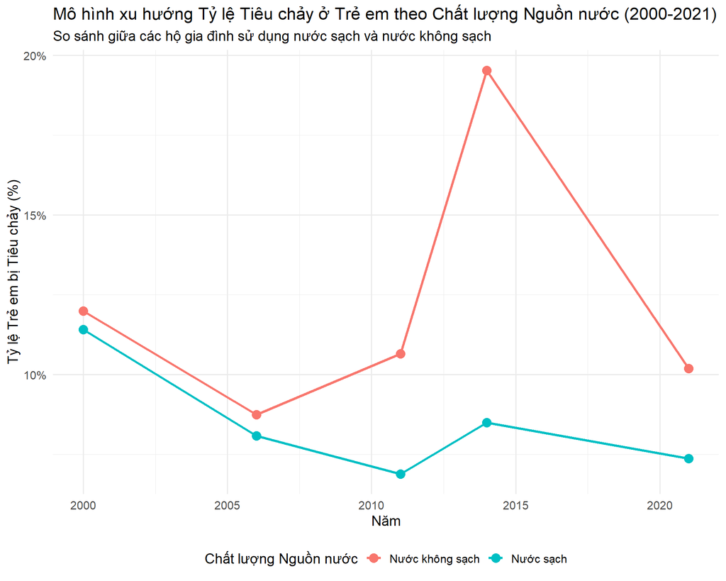